# Project: Investigating No-Show Medical Appointments

- Introduction
- Data Wrangling
- Exploratory Data Analysis
- Conclusions

## Introduction

I have selected the No-Show Appointments data set to analyze. This data set includes information for roughly 100k medical appointments in Brazil and is focused on the question of whether or not patients show up for their appointment.

In my analysis I plan to explore how each factor effects the rate of patients not attending their appointments.  
More specifically what external factors make a difference in the No-Show rate and what medical factors make a difference in the No-Show rate.  
The data set includes the following variables:  
PatientId: the identification number of each patient  
AppointmentID: the identification of each appointment  
Gender: Male or Female  
AppointmentDay: the day of the actual appointment  
ScheduledDay: the day someone called or registered for the appointment  
Age: how old the patient is at the time of the appointment  
Neighbourhood: where the hospital is that the appointment takes place  
Scholarship: whether or not the patient is on Brazil's social welfare program  
Hipertension: whether or not the patient suffers from Hypertension  
Diabetes: whether or not the patient suffers from Diabetes  
Alcoholism: whether or not the patient suffers from Alcohol dependency  
Handcap: whether or not the patient is handicapped  
SMS_received: whether or not the patient recieved 1 or more reminder messages  
No-show: whether or not the patient was at their appointment

```python
# loading data and packages needed for analysis and visualization
import numpy as np
import pandas as pd
import matplotlib.pyplot as plt
%matplotlib inline
plt.style.use('ggplot')

df = pd.read_csv('noshowappointments-kagglev2-may-2016.csv')
```

## Data Wrangling

### General Properties

```python
# View the first 5 lines of data in order to assess general properties
df.head()
```

|  | PatientId | AppointmentID | Gender | ScheduledDay | AppointmentDay | Age | Neighbourhood | Scholarship | Hipertension | Diabetes | Alcoholism | Handcap | SMS_received | No-show |
| --- | --- | --- | --- | --- | --- | --- | --- | --- | --- | --- | --- | --- | --- | --- |
| 0 | 2.987250e+13 | 5642903 | F | 2016-04-29T18:38:08Z | 2016-04-29T00:00:00Z | 62 | JARDIM DA PENHA | 0 | 1 | 0 | 0 | 0 | 0 | No |
| 1 | 5.589978e+14 | 5642503 | M | 2016-04-29T16:08:27Z | 2016-04-29T00:00:00Z | 56 | JARDIM DA PENHA | 0 | 0 | 0 | 0 | 0 | 0 | No |
| 2 | 4.262962e+12 | 5642549 | F | 2016-04-29T16:19:04Z | 2016-04-29T00:00:00Z | 62 | MATA DA PRAIA | 0 | 0 | 0 | 0 | 0 | 0 | No |
| 3 | 8.679512e+11 | 5642828 | F | 2016-04-29T17:29:31Z | 2016-04-29T00:00:00Z | 8 | PONTAL DE CAMBURI | 0 | 0 | 0 | 0 | 0 | 0 | No |
| 4 | 8.841186e+12 | 5642494 | F | 2016-04-29T16:07:23Z | 2016-04-29T00:00:00Z | 56 | JARDIM DA PENHA | 0 | 1 | 1 | 0 | 0 | 0 | No |

### Data Cleaning

#### Renaming of columns, reformatting data, dropping of columns, and addition of columns

```python
# In order to follow formatting best practices
df.rename(index=str, columns={"PatientId": "patient_id", "AppointmentID": "appointment_id", "Gender": "gender",
                              "ScheduledDay": "scheduled_day", "AppointmentDay": "appointment_day", "Age": "age",
                              "Neighbourhood": "neighborhood", "Scholarship": "scholarship",
                              "Hipertension": "hypertension", "Diabetes": "diabetes", "Alcoholism": "alcoholism",
                              "Handcap": "handicap", "No-show": "no_show"}, inplace=True)
df.head()
```

|  | patient_id | appointment_id | gender | scheduled_day | appointment_day | age | neighborhood | scholarship | hypertension | diabetes | alcoholism | handicap | SMS_received | no_show |
| --- | --- | --- | --- | --- | --- | --- | --- | --- | --- | --- | --- | --- | --- | --- |
| 0 | 2.987250e+13 | 5642903 | F | 2016-04-29T18:38:08Z | 2016-04-29T00:00:00Z | 62 | JARDIM DA PENHA | 0 | 1 | 0 | 0 | 0 | 0 | No |
| 1 | 5.589978e+14 | 5642503 | M | 2016-04-29T16:08:27Z | 2016-04-29T00:00:00Z | 56 | JARDIM DA PENHA | 0 | 0 | 0 | 0 | 0 | 0 | No |
| 2 | 4.262962e+12 | 5642549 | F | 2016-04-29T16:19:04Z | 2016-04-29T00:00:00Z | 62 | MATA DA PRAIA | 0 | 0 | 0 | 0 | 0 | 0 | No |
| 3 | 8.679512e+11 | 5642828 | F | 2016-04-29T17:29:31Z | 2016-04-29T00:00:00Z | 8 | PONTAL DE CAMBURI | 0 | 0 | 0 | 0 | 0 | 0 | No |
| 4 | 8.841186e+12 | 5642494 | F | 2016-04-29T16:07:23Z | 2016-04-29T00:00:00Z | 56 | JARDIM DA PENHA | 0 | 1 | 1 | 0 | 0 | 0 | No |

```python
df.info()
```

```
<class 'pandas.core.frame.DataFrame'>
Index: 110527 entries, 0 to 110526
Data columns (total 14 columns):
patient_id         110527 non-null float64
appointment_id     110527 non-null int64
gender             110527 non-null object
scheduled_day      110527 non-null object
appointment_day    110527 non-null object
age                110527 non-null int64
neighborhood       110527 non-null object
scholarship        110527 non-null int64
hypertension       110527 non-null int64
diabetes           110527 non-null int64
alcoholism         110527 non-null int64
handicap           110527 non-null int64
SMS_received       110527 non-null int64
no_show            110527 non-null object
dtypes: float64(1), int64(8), object(5)
memory usage: 12.6+ MB
```

```python
# changing formatting for better analysis
df.no_show.replace(('Yes', 'No'), (1, 0), inplace=True)
df.head()
```

|  | patient_id | appointment_id | gender | scheduled_day | appointment_day | age | neighborhood | scholarship | hypertension | diabetes | alcoholism | handicap | SMS_received | no_show |
| --- | --- | --- | --- | --- | --- | --- | --- | --- | --- | --- | --- | --- | --- | --- |
| 0 | 2.987250e+13 | 5642903 | F | 2016-04-29T18:38:08Z | 2016-04-29T00:00:00Z | 62 | JARDIM DA PENHA | 0 | 1 | 0 | 0 | 0 | 0 | 0 |
| 1 | 5.589978e+14 | 5642503 | M | 2016-04-29T16:08:27Z | 2016-04-29T00:00:00Z | 56 | JARDIM DA PENHA | 0 | 0 | 0 | 0 | 0 | 0 | 0 |
| 2 | 4.262962e+12 | 5642549 | F | 2016-04-29T16:19:04Z | 2016-04-29T00:00:00Z | 62 | MATA DA PRAIA | 0 | 0 | 0 | 0 | 0 | 0 | 0 |
| 3 | 8.679512e+11 | 5642828 | F | 2016-04-29T17:29:31Z | 2016-04-29T00:00:00Z | 8 | PONTAL DE CAMBURI | 0 | 0 | 0 | 0 | 0 | 0 | 0 |
| 4 | 8.841186e+12 | 5642494 | F | 2016-04-29T16:07:23Z | 2016-04-29T00:00:00Z | 56 | JARDIM DA PENHA | 0 | 1 | 1 | 0 | 0 | 0 | 0 |

```python
# changing formatting for better analysis
df.patient_id = df.patient_id.apply(int)
df.scheduled_day = df.scheduled_day.apply(np.datetime64)
df.appointment_day = df.appointment_day.apply(np.datetime64)
df.scheduled_day.head(1), df.appointment_day.head(1), df.patient_id.head(1)
```

```
(0   2016-04-29 18:38:08
 Name: scheduled_day, dtype: datetime64[ns], 0   2016-04-29
 Name: appointment_day, dtype: datetime64[ns], 0    29872499824296
 Name: patient_id, dtype: int64)
```

```python
# see how many patients in data set to determine dropping AppointmentID column
df.patient_id.nunique()
```

```
62299
```

```python
# each appointment ID is unique so it is not useful for analysis
df.drop(columns='appointment_id', inplace=True)
```

```python
# data set documentation claims this is a true or false
#results are inconsistent with that fact
df.handicap.unique()
```

```
array([0, 1, 2, 3, 4])
```

```python
# as a result of that inconsistency it should be dropped
df.drop(columns='handicap', inplace=True)
```

```python
# addition of day of the week column
df['apt_weekday'] = df['appointment_day'].dt.day_name()
```

```python
# reassess data types and check addition of column
df.info()
```

```
<class 'pandas.core.frame.DataFrame'>
Index: 110527 entries, 0 to 110526
Data columns (total 13 columns):
patient_id         110527 non-null int64
gender             110527 non-null object
scheduled_day      110527 non-null datetime64[ns]
appointment_day    110527 non-null datetime64[ns]
age                110527 non-null int64
neighborhood       110527 non-null object
scholarship        110527 non-null int64
hypertension       110527 non-null int64
diabetes           110527 non-null int64
alcoholism         110527 non-null int64
SMS_received       110527 non-null int64
no_show            110527 non-null int64
apt_weekday        110527 non-null object
dtypes: datetime64[ns](2), int64(8), object(3)
memory usage: 11.8+ MB
```

## Exploratory Data Analysis

### Research Question 1: What external factors make a difference in the No-Show rate?

```python
df.no_show.mean()
```

```
0.20193255946510807
```

Patients did not attend 20% of the total scheduled appointments.

```python
df.SMS_received.mean()
```

```
0.32102563174608917
```

32% of patients received a text message reminder about their appointment.

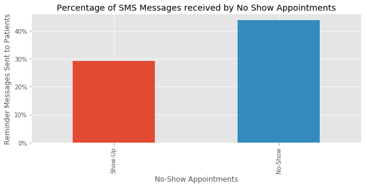

```python
# evaluate the relationship between message reminders and no-show appointments
df.groupby('no_show').SMS_received.mean().plot(kind='bar', figsize=(10, 4))
plt.gca().set_yticklabels(['{:.0f}%'.format(x*100) for x in plt.gca().get_yticks()])
plt.gca().set_xticklabels(('Show-Up', 'No-Show'))
plt.gca().set_title(("Percentage of SMS Messages received by No Show Appointments"))
plt.gca().set_xlabel(("No-Show Appointments"))
plt.gca().set_ylabel(("Reminder Messages Sent to Patients"));
```

This demonstrates that patients are more likely to attend their appointment if they do not receive a reminder about it.

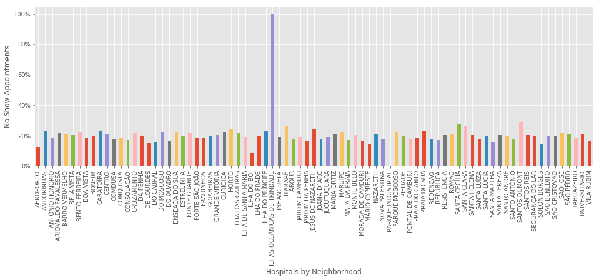

```python
# evaluate the relationship between hospital neighborhoods and no-show appoinments
df.groupby('neighborhood').no_show.mean().plot(kind='bar', figsize=(17, 5));
plt.gca().set_yticklabels(['{:.0f}%'.format(x*100) for x in plt.gca().get_yticks()])
plt.gca().set_ylabel(("No Show Appointments"))
plt.gca().set_xlabel(("Hospitals by Neighborhood"));
```

This visualized that most hospitals had similar no-show appointment percentages.  
Note: There is one outlier and upon further investigation that hospital had only two appointments scheduled, both of which were no-shows, so it is not statistically signifigant.

```python
# evaluate the relationship between age and no-show appointments
df.groupby('no_show').age.mean()
```

```
no_show
0    37.790064
1    34.317667
Name: age, dtype: float64
```

This demonstrates that on average older patients are *slightly* more likely to attend their appointments.

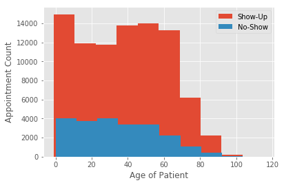

```python
# visualization of the relationship between message reminders and no-show appointments
labels = ('Show-Up', 'No-Show')
df.groupby('no_show').age.plot(kind='hist')
plt.gca().set_xlabel(("Age of Patient"))
plt.gca().set_ylabel(("Appointment Count"))
plt.gca().legend(labels);
```

This demonstrates that age has an impact on how often people go to the doctor. For instance, patients in their children and teens are more likely to attend their doctors appointments when total number of appointments is taken into account and there is a drop off in appointments of patients in their 20s and 30s, but roughly 4,000 of them are no-shows.

```python
# evaluate the relationship between gender and no-show appointments
df.groupby('gender').no_show.mean()
```

```
gender
F    0.203146
M    0.199679
Name: no_show, dtype: float64
```

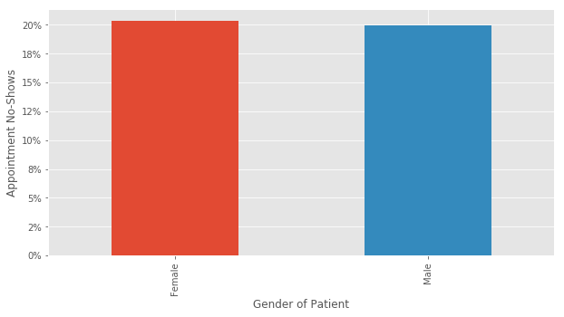

```python
# visualize the relationship between gender and no-show appointments
df.groupby('gender').no_show.mean().plot(kind='bar', figsize=(10, 5))
plt.gca().set_yticklabels(['{:.0f}%'.format(x*100) for x in plt.gca().get_yticks()])
plt.gca().set_xticklabels(('Female', 'Male'))
plt.gca().set_ylabel(("Appointment No-Shows"))
plt.gca().set_xlabel(("Gender of Patient"));
```

This shows that in proportion to how many appointments there are gender has little effect on the rate of people not showing up to their appointments.

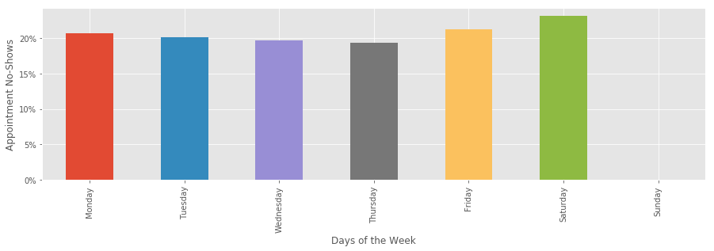

```python
# evaluate the relationship between the day of the week and no-show appointments
day_order = ["Monday", "Tuesday", "Wednesday", "Thursday", "Friday", "Saturday", "Sunday"]
df_1 = df.groupby('apt_weekday').no_show.mean()

df_1.reindex(day_order).plot(kind='bar', figsize=(15, 4))
plt.gca().set_yticklabels(['{:.0f}%'.format(x*100) for x in plt.gca().get_yticks()])
plt.gca().set_ylabel(("Appointment No-Shows"))
plt.gca().set_xlabel(("Days of the Week"));
```

This demonstrates that there is a slight fluctuation in no-show appointments depending on the day of the week with Saturday having the greatest number of no-show appointments.

```python
# evaluate the correlation between different factors in the data set
df.corr(method = 'pearson')
```

|  | patient_id | age | scholarship | hypertension | diabetes | alcoholism | SMS_received | no_show |
| --- | --- | --- | --- | --- | --- | --- | --- | --- |
| patient_id | 1.000000 | -0.004139 | -0.002880 | -0.006441 | 0.001605 | 0.011011 | -0.009749 | -0.001461 |
| age | -0.004139 | 1.000000 | -0.092457 | 0.504586 | 0.292391 | 0.095811 | 0.012643 | -0.060319 |
| scholarship | -0.002880 | -0.092457 | 1.000000 | -0.019729 | -0.024894 | 0.035022 | 0.001194 | 0.029135 |
| hypertension | -0.006441 | 0.504586 | -0.019729 | 1.000000 | 0.433086 | 0.087971 | -0.006267 | -0.035701 |
| diabetes | 0.001605 | 0.292391 | -0.024894 | 0.433086 | 1.000000 | 0.018474 | -0.014550 | -0.015180 |
| alcoholism | 0.011011 | 0.095811 | 0.035022 | 0.087971 | 0.018474 | 1.000000 | -0.026147 | -0.000196 |
| SMS_received | -0.009749 | 0.012643 | 0.001194 | -0.006267 | -0.014550 | -0.026147 | 1.000000 | 0.126431 |
| no_show | -0.001461 | -0.060319 | 0.029135 | -0.035701 | -0.015180 | -0.000196 | 0.126431 | 1.000000 |

This shows that in the respect of no_show appointments there is no one factor that has a strong correlation with cancelled appointments. The strongest positive correlation is between the SMS_received and no_show appointments columns which indicates that a patient is *slightly* more likely to skip their appointment if they receive a text reminder.

## Research Question 2: What medical factors make a difference in the No-Show Appointment Rate?

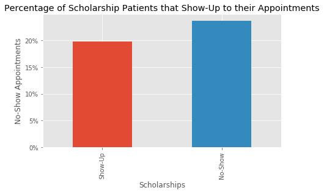

```python
df.groupby('scholarship').no_show.mean().plot(kind='bar', figsize=(7, 4));
plt.gca().set_yticklabels(['{:.0f}%'.format(x*100) for x in plt.gca().get_yticks()])
plt.gca().set_ylabel(("No-Show Appointments"))
plt.gca().set_xlabel(("Scholarships"));
plt.gca().set_xticklabels(('Show-Up', 'No-Show'))
plt.gca().set_title(("Percentage of Scholarship Patients that Show-Up to their Appointments"));
```

This visualization demonstrates that patients on Brazil's social welfare system are somewhat more likely not to attend their appointments than those not on social welfare.

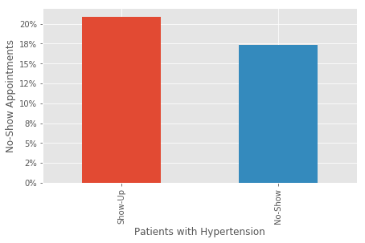

```python
df.groupby('hypertension').no_show.mean().plot(kind='bar', figsize=(7, 4));
plt.gca().set_yticklabels(['{:.0f}%'.format(x*100) for x in plt.gca().get_yticks()])
plt.gca().set_ylabel(("No-Show Appointments"))
plt.gca().set_xlabel(("Patients with Hypertension"))
plt.gca().set_xticklabels(('Show-Up', 'No-Show'));
```

This visualization demonstrates that patients suffering from Hypertension are somewhat more likely to show up to their appointments than those without the illness.

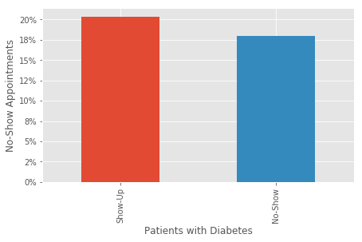

```python
df.groupby('diabetes').no_show.mean().plot(kind='bar', figsize=(7, 4));
plt.gca().set_yticklabels(['{:.0f}%'.format(x*100) for x in plt.gca().get_yticks()])
plt.gca().set_ylabel(("No-Show Appointments"))
plt.gca().set_xlabel(("Patients with Diabetes"))
plt.gca().set_xticklabels(('Show-Up', 'No-Show'));
```

This visualization demonstrates that patients suffering from Diabetes are somewhat more likely to show up to their appointments than those without the illness.

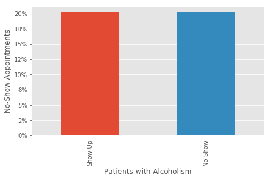

```python
df.groupby('alcoholism').no_show.mean().plot(kind='bar', figsize=(7, 4));
plt.gca().set_yticklabels(['{:.0f}%'.format(x*100) for x in plt.gca().get_yticks()])
plt.gca().set_ylabel(("No-Show Appointments"))
plt.gca().set_xlabel(("Patients with Alcoholism"))
plt.gca().set_xticklabels(('Show-Up', 'No-Show'));
```

## Conclusions

Roughly 20% of patients to not attend the appointments they scheduled. The data set provides information about each appointment such as the age of the patients, where the appointment was located, and a few possible diseases that each patient suffers from. No one factor can be pointed to as a cause for a patient not to show up, but there are a few factors that are correlated with higher or lower rates of no-show appointments.

Sources: Data Set: https://s3.amazonaws.com/video.udacity-data.com/topher/2018/July/5b57919a_data-set-options/data-set-options.pdf 4/15/2019 Create charts with percentage in y-axis: https://stackoverflow.com/questions/31357611/format-y-axis-as-percent 4/15/2019 Convert string with date in it to date format: https://stackoverflow.com/questions/30222533/create-a-day-of-week-column-in-a-pandas-dataframe-using-python 4/16/2019 Change the order of day of week chart: https://stackoverflow.com/questions/47255746/change-order-on-x-axis-for-matplotlib-chart 4/18/2019